# STAT 490 Network Models and Simulations

## Simulating a Forest Wildfire

### Load R libraries

```r
library(rmarkdown)
library(knitr)
library(igraph)
library(stringr)
library(tidyverse)
```

## Warm-up Simulation 1

### Exercise 1:

Deconstruct the Monty Hall Problem into four simpler, consecutive procedures and identify the possible outcomes and corresponding probabilities in each procedure.

```
  Hide the Prize behind a door: 1/3 for each door
  Choose a door : 1/3 for all 3 door
  Reveal the door: If the door has the prize, 1/2 for the other 2 doors. If the door doesnt have the prize, 1.0 for the only remaining door that doesnt have the prize.
  Switch the door:1.0 to switch to the only remaining door(since the door revealed doesn't have the prize)
```

### Exercise 2:

Write a segment of code to simulate a single trial of the Monty Hall Problem and print a value of TRUE of FALSE depending on whether or not switching doors resulted in the contestant winning the prize.

```r
MontySim <- function()
{
  Prize <- sample(c("A", "B", "C"), size = 1, prob=c(1/3,1/3,1/3))
  prob <- 1/3
  choice <- sample(c("A", "B", "C"), size = 1,prob=c(1/3,1/3,1/3))
  prob <- prob * 1/3
  revealSample <- c()
  revealProb <- c()
  reveal <- ""
  switch <- ""
  result = FALSE
  if(Prize == choice)
  {
    if(Prize == "A")
    {
      revealSample = c("B", "C")
    } else if(Prize == "B")
    {
       revealSample =c("A", "C")
    }else
    {
       revealSample =c("A", "B")
    }
    revealProb <- c(0.5, 0.5)
    reveal <- sample(x=revealSample,size=1, prob=revealProb)
    switch <- revealSample[revealSample != reveal]
    prob=prob*0.5
  }else
  {
    if(Prize == "A")
    {
      if(choice == "B")
       {
        reveal <- "C"
      }else
      {
        reveal <- "B"
      }
      switch <- "A"
    }
    if(Prize == "B")
    {
      if(choice == "A")
       {
        reveal <- "C"
      }else
      {
        reveal <- "A"
      }
      switch <- "B"
    }
    if(Prize == "C")
    {
      if(choice == "B")
       {
        reveal <- "A"
      }else
      {
        reveal <- "B"
      }
      switch <- "C"
    }
   }
  if(switch == Prize)
  {
    result = TRUE
  }
  return(result)
}
print(MontySim())
```

```
## [1] FALSE
```

```r
#answer <- replicate(1000, result)
```

### Exercise 3:

Use a For Loop to simulate 100 trials of the Monty Hall Problem, record whether or not the contestant won the prize in each trial, and print out the results of each trial as a single vector of values.

```r
visProb <- c()
trueV <- 0
numofTrials <- c()
answer <- replicate(1000, MontySim())
for (i in (1:length(answer)))
{
  if(answer[i])
  {
    trueV <- trueV+1
  }
  visProb[i] <- trueV/i
  numofTrials[i] <- i
  print(answer[i]);
}
```

```
## [1] TRUE
## [1] FALSE
## [1] TRUE
## [1] TRUE
## [1] TRUE
## [1] TRUE
## [1] FALSE
## [1] FALSE
## [1] TRUE
## [1] TRUE
## [1] TRUE
## [1] TRUE
## [1] FALSE
## [1] FALSE
## [1] TRUE
```

[output cut: 985 more lines]

### Exercise 4:

Visualize the cumulative probability of the contestant winning the prize if they switched doors.

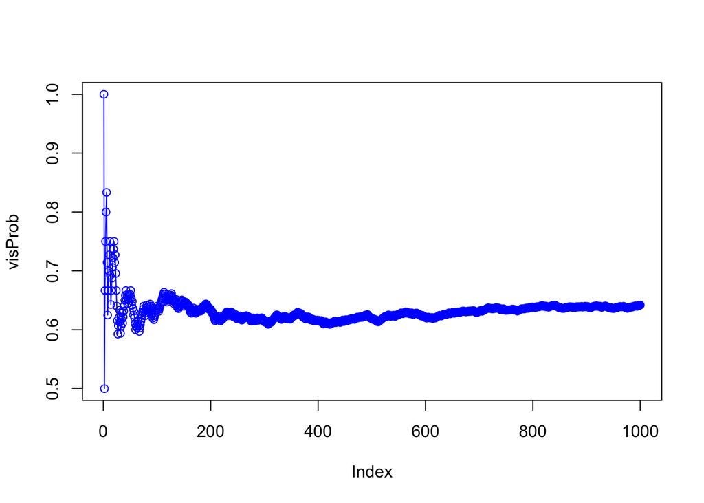

```r
plot(visProb, type="o", col="blue")
```

```r
#visProb[length(answer)]
```

### Exercise 5:

Discuss whether or not it is more advantageous for a contestant to switch doors after a different door has been revealed.

[output not shown]

## Warm-Up Simulation 2

### Exercise 6:

Write a segment of code to simulate a single trial of a one-on-one game of Blackjack and print a value of TRUE or FALSE depending on whether or not hitting on 16 resulted in the player losing (i.e., getting higher than a 21).

```r
types = "SHDC"
cards = "A23456789JQK"
Deck <- c()
probab <- c()
x <- 1
for (i in 1:str_length(cards))
{
  for (j in 1:str_length(types))
  {
    Deck [x] <- paste(substring(cards,i,i),substring(types,j,j),sep="")
    probab[x] <- 1/52
    x <- x+1
  }
  if(substring(cards,i,i) == "9")
    {
       for (j in 1:str_length(types))
      {
        Deck[x] <- paste("10", substring(types,j,j),sep="")
        probab[x] <- 1/52
        x <- x+1
       }
    }
}
value = replicate(4, c(11,2,3,4,5,6,7,8,9,10,10,10,10))
number = c()
for (i in 1:length(value))
{
  number[i] = value[i]
}
CardDeck <- data.frame(Deck, number, probab)

blackJack <- function()
{
  result <- NA
  trial <- sample(x=CardDeck$Deck, size = 1, prob = CardDeck$probab)
  CardDeck$probab[CardDeck$Deck == trial] <- 0

  secTrial <- sample(x=CardDeck$Deck, size = 1, prob = CardDeck$probab)
  CardDeck$probab[CardDeck$Deck == secTrial] <- 0

  thirdTrial <- sample(x=CardDeck$Deck, size = 1, prob = CardDeck$probab)
  CardDeck$probab[CardDeck$Deck == thirdTrial] <- 0

  fourTrial <- sample(x=CardDeck$Deck, size = 1, prob = CardDeck$probab)
  CardDeck$probab[CardDeck$Deck == fourTrial] <- 0

  playerSum <- CardDeck$number[CardDeck$Deck == trial] + CardDeck$number[CardDeck$Deck ==  thirdTrial]
  if(playerSum == 16)
  {
    fiveTrial <-sample(x=CardDeck$Deck, size = 1, prob = CardDeck$probab)
    CardDeck$probab[CardDeck$Deck == fiveTrial] <- 0
    #print (playerSum + CardDeck$number[CardDeck$Deck == fiveTrial])
    if(playerSum + CardDeck$number[CardDeck$Deck == fiveTrial] <= 21)
    {
      result = FALSE
    }else
    {
     result = TRUE
    }
  }
  return(result)
}
```

### Exercise 7:

Use a For Loop to simulate one million trials of one-on-one games of Blackjack and record (not print) whether or not the player lost in each trial as a single vector of values.

```r
blackJackAnswer <- replicate(1000000, blackJack())
newblackjack<- blackJackAnswer[!is.na(blackJackAnswer)]
trueCounter <- 0
recorder <- c()
for (i in (1:length(newblackjack)))
{
  if(newblackjack[i] == TRUE)
  {
    trueCounter <- trueCounter + 1

  }

  recorder[i] = trueCounter/i

}

recorder[length(newblackjack)]
```

```
## [1] 0.6847758
```

### Exercise 8:

Visualize the cumulative probability of the contestant losing if they hit on 16.

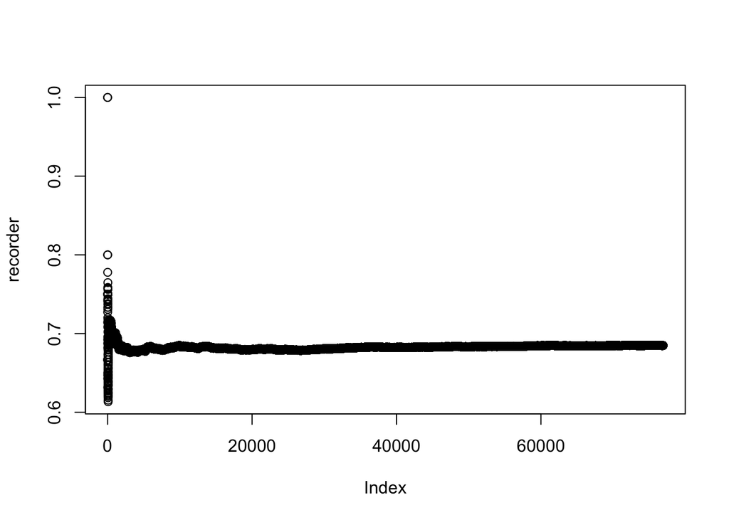

```r
plot(recorder)
```

### Exercise 9:

Discuss whether or not it is more advantageous for a player to hit on 16, keeping in mind that the probability of losing if you don’t hit on 16 is approximately 69.31%.

[output not shown]

## Simulating a Fire (Matrix)

### Exercise 10:

Write a segment of code to simulate the spread of a fire over 100 time steps across a 30 x 30 matrix and record the number of burning trees at each step.

```r
forest <- function ()
{
  forMatrix <- matrix(0L, nrow = 30, ncol = 30)
  for(i in 1:nrow(forMatrix))
  {
    for(j in 1:ncol(forMatrix))
    {
      forMatrix[i,j] <- rbinom(1,1,.7)
    }
  }
    i <- sample(1:30, size = 1)
    j <- sample(1:30, size = 1)
    forMatrix[i,j] <- 2
  return(forMatrix)
}

forestMat <- forest()
recordMatrix <- forestMat
#forestMatrix <- c()
treeCount <<- matrix(0L, nrow = 100)

timeMat <- c()

forestFire <- function()
{

  forestMatrix <- forest()
  for(k in 1:100)
  {
    count <- 0
    for(i in 1:nrow(forestMatrix))
  {
    for(j in 1:ncol(forestMatrix))
    {

      if(forestMatrix[i,j] == 2)
      {
        count <- count +1
        if(i == 30)
        {
          if(forestMatrix[i-1,j] == 1)
          {
            recordMatrix[i-1,j] <- 2
          }
        }else if(i == 1 )
        {
          if(forestMatrix[i+1,j] == 1)
          {
            recordMatrix[i+1,j] <- 2
          }
        }
        else
        {
          if(forestMatrix[i-1,j] == 1)
          {
            recordMatrix[i-1,j] <- 2
          }
          if(forestMatrix[i+1,j] == 1)
          {
            recordMatrix[i+1,j] <- 2
          }

        }
        if(j == 30)
        {
          if(forestMatrix[i,j-1] == 1)
          {
            recordMatrix[i, j-1] <- 2
          }
        }else  if(j == 1)
        {
           if(forestMatrix[i,j+1] == 1)
          {
            recordMatrix[i, j+1] <- 2
          }
        }
        else
        {
          if(forestMatrix[i,j-1] == 1)
          {
            recordMatrix[i, j-1] <- 2
          }
           if(forestMatrix[i,j+1] == 1)
          {
            recordMatrix[i, j+1] <- 2
          }
        }

        recordMatrix[i,j] <- 0
      }#if
      else if(forestMatrix[i,j] == 0)
      {
        hold <- runif(1)
        if(hold <= 0.015)
        {
          recordMatrix[i,j] = 1
        }
      }
    }#Inner-for
  }#Outer-for
    treeCount[k] <<- count

    forestMatrix = recordMatrix
    timeMat[k] = k
  }

  return(recordMatrix)
}#forestFire
```

### Exercise 11:

Visualize the spatial distribution of empty spaces, trees, and burning trees at the start and at the end of a single trial of this Forest Fire.

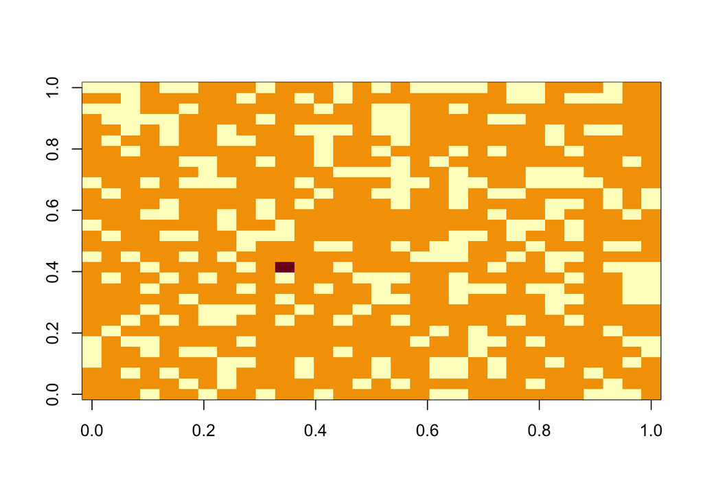

```r
image(forestMat)
```

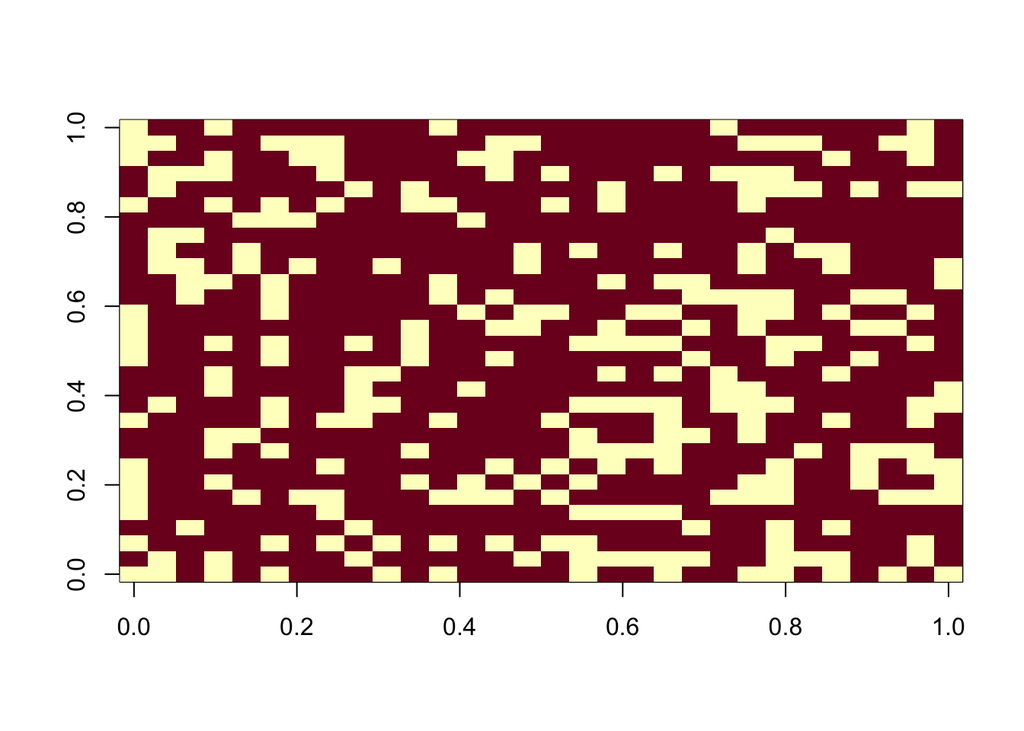

```r
image(forestFire())
```

### Exercise 12:

Produce a plot of the number of burning trees over time.

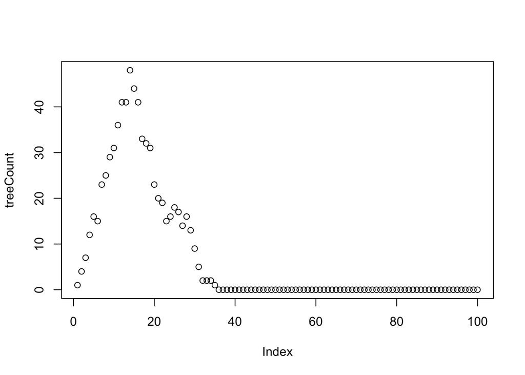

```r
#forestFire()
plot(treeCount)
```

### Exercise 13:

Use a For Loop to simulate 1000 trials of this Forest Fire and produce a plot of the average number of burning trees over time.

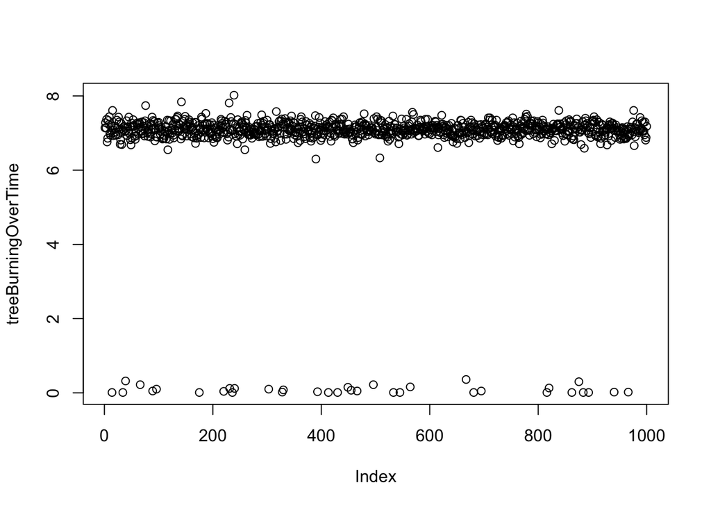

```r
treeCount <<- c()
timeMat <<- c()

forestFire <- function()
{

  forestMatrix <- forest()
  recordMatrix <- forestMatrix
  for(k in 1:100)
  {
    count <- 0
    for(i in 1:nrow(forestMatrix))
  {
    for(j in 1:ncol(forestMatrix))
    {

      if(forestMatrix[i,j] == 2)
      {
        count <- count +1
        if(i == 30)
        {
          if(forestMatrix[i-1,j] == 1)
          {
            recordMatrix[i-1,j] <- 2
          }
        }else if(i == 1 )
        {
          if(forestMatrix[i+1,j] == 1)
          {
            recordMatrix[i+1,j] <- 2
          }
        }
        else
        {
          if(forestMatrix[i-1,j] == 1)
          {
            recordMatrix[i-1,j] <- 2
          }
          if(forestMatrix[i+1,j] == 1)
          {
            recordMatrix[i+1,j] <- 2
          }

        }
        if(j == 30)
        {
          if(forestMatrix[i,j-1] == 1)
          {
            recordMatrix[i, j-1] <- 2
          }
        }else  if(j == 1)
        {
           if(forestMatrix[i,j+1] == 1)
          {
            recordMatrix[i, j+1] <- 2
          }
        }
        else
        {
          if(forestMatrix[i,j-1] == 1)
          {
            recordMatrix[i, j-1] <- 2
          }
           if(forestMatrix[i,j+1] == 1)
          {
            recordMatrix[i, j+1] <- 2
          }
        }

        recordMatrix[i,j] <- 0
      }#if
      else if(forestMatrix[i,j] == 0)
      {
        hold <- runif(1)
        if(hold <= 0.015)
        {
          recordMatrix[i,j] = 1
        }
      }
    }#Inner-for
  }#Outer-for
    treeCount[k] <<- count

    forestMatrix = recordMatrix
    timeMat[k] <<- k
  }

  return(mean(treeCount))
}#forestFire
treeBurningOverTime <- c()
for( p in 1:1000)
{
  treeBurningOverTime[p] <- forestFire()
}
plot(treeBurningOverTime)
```

### Exercise 14:

Discuss any patterns you observe in exercise (13).

## Simulating a Fire (Network)

### Exercise 15:

Write a segment of code to simulate the spread of a fire across a 30 x 30 lattice network using exercise (10) as a template.

```r
network <- igraph::graph.lattice(c(30,30))
forestNetwork <- function ()
{
  for(i in 1:900)
  {
   #v(G)$state <- rbinom(900,1,0.7)
      hold <- runif(1)
      if(hold <= .7)
      {
       V(network)$state[i] <- "tree"
       V(network)$color[i] <- "green"
      }
      else
      {
        V(network)$state[i] <- "empty"
       V(network)$color[i] <- "white"
      }
  }
   num <- sample(1:90, size = 1)
  V(network)$state[num] <- "Burntree"
  V(network)$color[i] <- "red"
  return(network)
}
```

### Exercise 16:

Visualize the spatial distribution of empty spaces, trees, and burning trees at the start and at the end of a single trial of this Forest Fire.

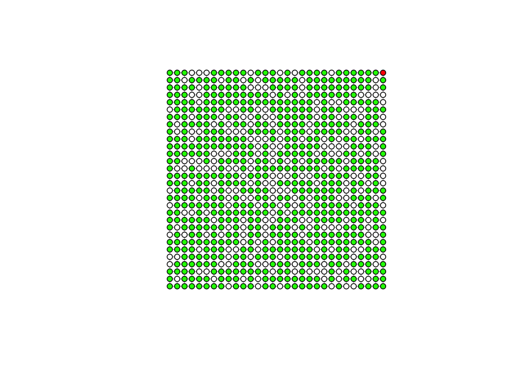

```r
net <- forestNetwork()
plot(net, layout = layout.grid(net), vertex.size = 5, vertex.label = NA)
```

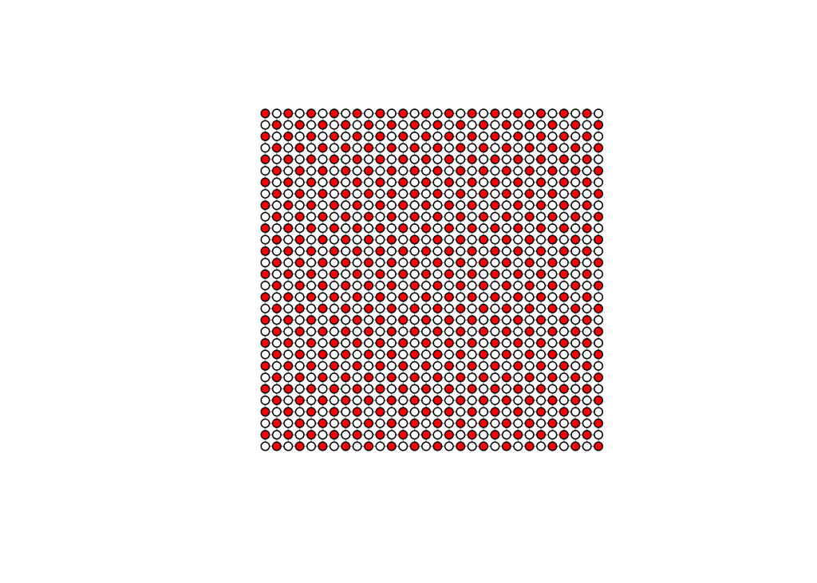

```r
treeCountN <<- matrix(0L, nrow = 100)
forestFireNet <- function()
{
  networkN <- forestNetwork()
  recordNet <- net
  for(k in 1:100)
  {
    count <- 0
    for(i in 1:900)
    {
      if(V(networkN)$state[i] == "Burntree")
      {
        count <- count +1
        newFire <- neighbors(recordNet,i)
        V(recordNet)$state[newFire] <- "Burntree"
        V(recordNet)$color[newFire] <- "red"
        V(recordNet)$state[i] <- "empty"
        V(recordNet)$color[i] <- "white"

      }#if
       else if(V(networkN)$state[i] == "empty")
      {
        hold <- runif(1)
        if(hold <= .015)
        {
          V(recordNet)$state[i] <- "tree"
          V(recordNet)$color[i] <- "green"
        }
      }

    }#Outer-for
      networkN <- recordNet
      treeCountN[k] <<- count
  }
  return(networkN)
}
netN <- forestFireNet()
plot(netN, layout = layout.grid(netN), vertex.size = 5, vertex.label = NA)
```

### Exercise 17:

Produce a plot of the number of burning trees over time.

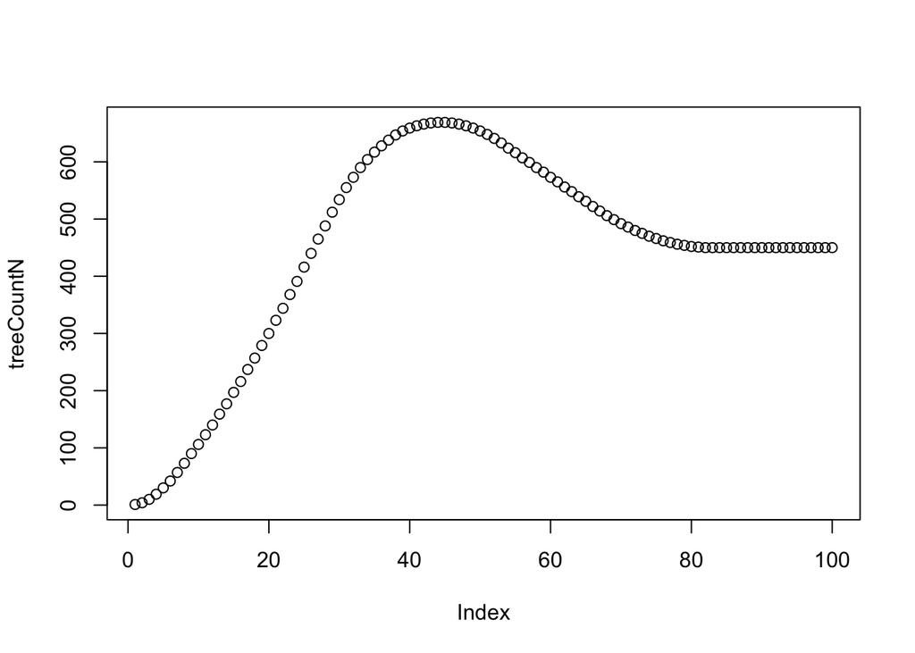

```r
plot(treeCountN)
```

### Exercise 18:

Write a function of the code in exercise (15) that takes p and q (the initial tree coverage) as arguments and returns the number of burning trees at each step.

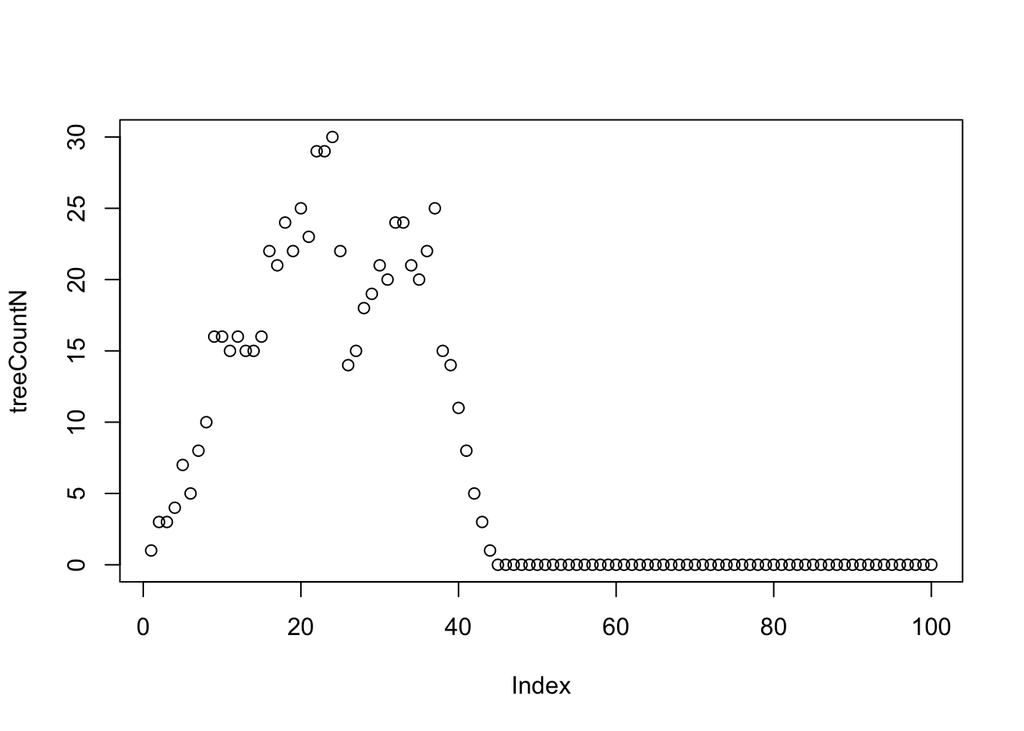

```r
networkN <- igraph::graph.lattice(c(30,30))
treeCountN <<- matrix(0L, nrow = 100)
forestFireNetNew <- function(p,q)
{

     V(networkN)$state <- rbinom(900,1,q)
     V(networkN)$color[V(networkN)$state == 0] <- "white"
     V(networkN)$color[V(networkN)$state == 1] <- "green"


   num <- sample(1:900, size = 1)
  V(networkN)$state[num] <- 2
  V(networkN)$color[num] <- "red"
  recordNet <- networkN

  for(k in 1:50)
  {

      V(recordNet)$state[intersect(unlist(adjacent_vertices(networkN, which(V(networkN)$state == 2))), which(V(networkN)$state == 1))] <- 2
      V(recordNet)$color[intersect(unlist(adjacent_vertices(networkN, which(V(networkN)$state == 2))), which(V(networkN)$state == 1))] <- "red"
      V(recordNet)$state[V(networkN)$state == 2] <- 0
      V(networkN)$color[V(networkN)$state == 2] <- "white"
      treeCountN[k] <<- length(intersect(unlist(adjacent_vertices(networkN, which(V(networkN)$state == 2))), which(V(networkN)$state == 1)))
      V(recordNet)$state[V(networkN)$state == 0] <- rbinom(sum(V(networkN)$state == 0),1,p)
      #V(recordNet)$state.isNa
      V(recordNet)$color[V(recordNet)$state == 1] <- "green"
      networkN = recordNet
      #p <- p + 0.05
  }
  return(treeCountN)
}
netNew <- forestFireNetNew(0.015, 0.70)
plot(treeCountN)
```

### Exercise 19:

Use a nested loop to record and visualize the effect of increasing p (while holding q = 0.70) on the average size of the fire (i.e., the maximum number of trees that burning at any single time step) across 1000 trials of this Forest Fire.

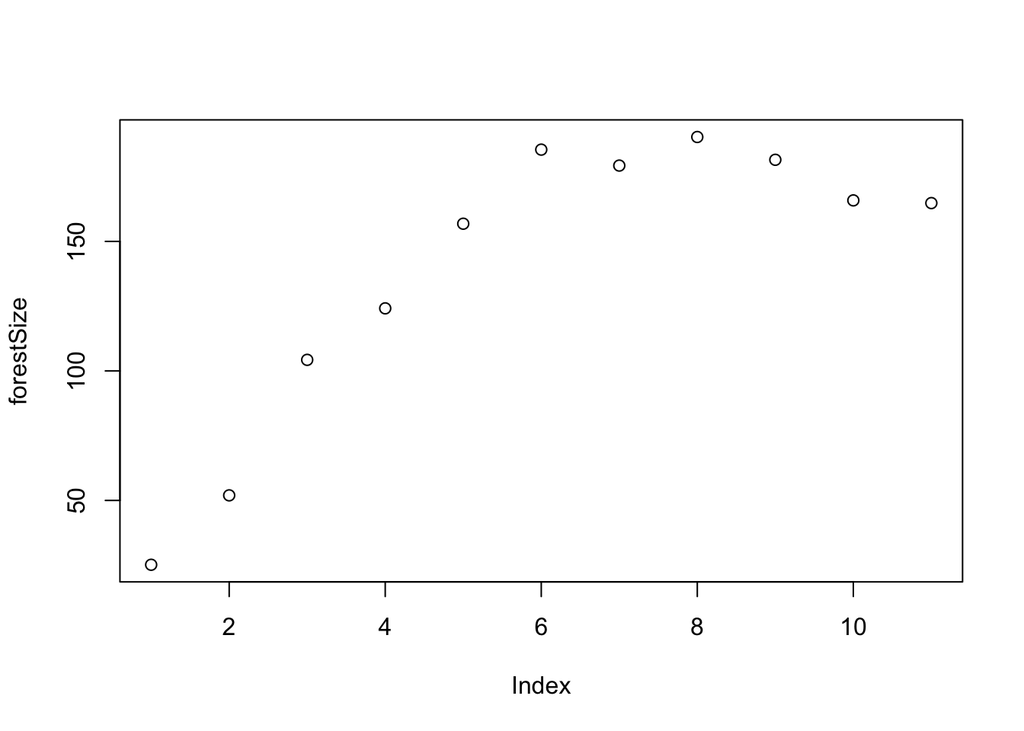

```r
## Increments 0.05-.1

forestFireNetNew <- function(p,q)
{
  networkN <- igraph::graph.lattice(c(30,30))
  treeCountN <<- matrix(0L, nrow = 50)
  V(networkN)$state <- rbinom(900,1,q)



   num <- sample(1:900, size = 1)
  V(networkN)$state[num] <- 2
  recordNet <- networkN

  for(k in 1:50)
  {

      V(recordNet)$state[intersect(unlist(adjacent_vertices(networkN, which(V(networkN)$state == 2))), which(V(networkN)$state == 1))] <- 2
      V(recordNet)$state[V(networkN)$state == 2] <- 0
      treeCountN[k] <<- length(intersect(unlist(adjacent_vertices(networkN, which(V(networkN)$state == 2))),  which(V(networkN)$state == 1)))
      V(recordNet)$state[V(networkN)$state == 0] <- rbinom(sum(V(networkN)$state == 0),1,p)
      networkN = recordNet

  }
  return(max(treeCountN))
}
count <- 1
forestSize <- c()
for (val in seq(0,1,by=0.1))
{
  forestSize[count] <- mean(replicate(25, forestFireNetNew(p=val, 0.70)))
  count <- count + 1
}

plot(forestSize)
```

### Exercise 20:

Discuss any patterns you observe in exercise (19).

[output not shown]

### Exercise 21:

Use a nested loop to record and visualize the effect of altering q (while holding p = 0.015) on the average size of the fire across 1000 trials of this Forest Fire.

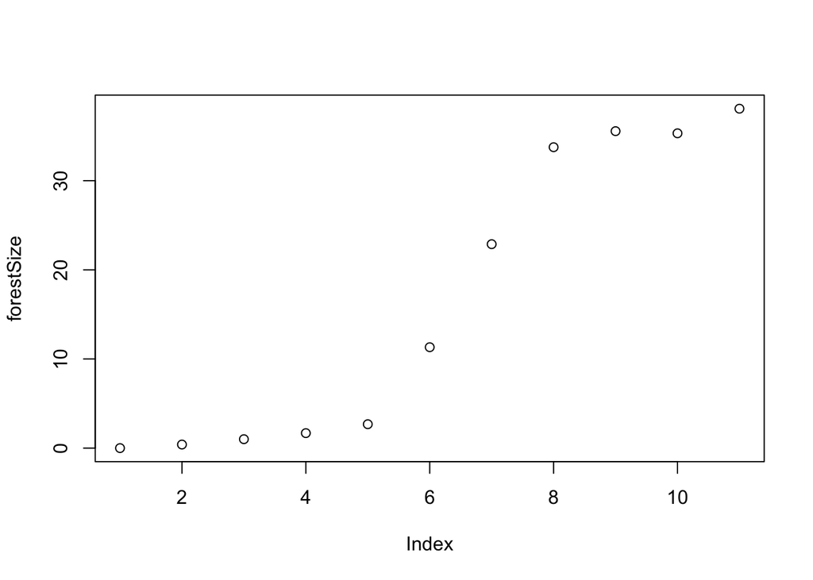

```r
networkN <- igraph::graph.lattice(c(30,30))
treeCountN <<- matrix(0L, nrow = 50)
forestFireNetNew <- function(p,q)
{

    V(networkN)$state <- rbinom(900,1,q)
    num <- sample(1:900, size = 1)
    V(networkN)$state[num] <- 2
    recordNet <- networkN

    for(k in 1:50)
    {

      V(recordNet)$state[intersect(unlist(adjacent_vertices(networkN, which(V(networkN)$state == 2))), which(V(networkN)$state == 1))] <- 2
      V(recordNet)$state[V(networkN)$state == 2] <- 0
      treeCountN[k] <<- length(intersect(unlist(adjacent_vertices(networkN, which(V(networkN)$state == 2))), which(V(networkN)$state == 1)))
      #hold <- length[V(networkN)$state == 0]
      V(recordNet)$state[V(networkN)$state == 0] <- rbinom(sum(V(networkN)$state == 0),1,p)
      networkN = recordNet

    }
    return(max(treeCountN))
}
#treeCountN <- replicate(100,
count <- 1
forestSize <- c()
for (val in seq(0,1,by=0.1))
{
  forestSize[count] <- mean(replicate(25, forestFireNetNew(0.015, q=val)))
  count <- count + 1
}


plot(forestSize)
```

### Exercise 22:

Discuss any patterns you observe in exercise (21).

```
Based on(21), we can say that the maximum number of burning trees drastically increased after 50% of tree coverage.
```

### Exercise 23:

Discuss how your answer to exercise (22) relates to prescribed burning in forests (i.e., intentional and controlled application of fire to a forest to decrease the risk of extreme forest wildfires).

```
Based on (19) and (21), it seems that intentional or controlled application of fire to a forest is good. Because, it helps in regenerating the trees as we are doing in our simulation.  In order to control the forest wildfire, it is advantageous to burn the trees before they reach 50% coverage. Otherwise, it would be extremely hard to control extreme forest wildfire.
```